# \vspace{1em}

The outputted image will correctly position the node labels with x-axis representing the node year, and y-axis representing the node path index. Light grey edges between two nodes represent parent-child relationships between those nodes. To enhance the visual understanding of how the path-of-interest fits into the entire graph structure, the nodes within the path are labelled in boldface, and connected with light-green boldfaced edges.

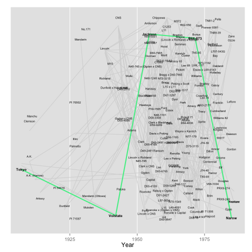

```r
plotTotalImage <- plotPathOnTree(path=path, ig=ig)
plotTotalImage
```

And this is where the explanation of the variable **binVector** (used as input parameters to the function **spreadTotalDF**) comes into play. As there is no uniform solution for this complicated problem, the **phyViz** package offers you the flexbility to changes these variables until you can optimize this image so that the text of the nodes of your tree overlap as little as possible. This can be done with a trial-and-error process by tweaking **binVector**'s order and length at the start.

Specifically, the length of **binVector** indicates how many bins of equal sizes should be allocated (where bins separate the vertices into groups of years). Theo order of **binVector** can be altered to avoid spatial collisions in labels.

The **binVector** will determine the order that increasing y index positions are repeatedly assigned to. For instance, if binVector = c(1,4,7,10,2,5,8,11,3,6,9,12), then y-axis position one will be assigned to a variety in the first bin of years, y-axis position two will be assigned to a variety in the fourth bin of years, …., and y-axis position thirteen will be assigned again to a variety in the first bin of years. This will be repreated until all varieties from all bins have been assigned in that order. This vector can help minimize overlap of the labelling of varieties, as varieites from the same bins (near each other on the x-axis for years) will not have consecutive y-axis values.

```r
plotTotalImage <- plotPathOnTree(path=path, ig=ig, binVector=1:12)
```

```r
plotTotalImage <- plotPathOnTree(path=path, ig=ig, binVector=1:2)
```

It may also be of interest to scientists studying phylogenetics to generate heat maps where the color of each index of the map indicates the distance or years between two vertices.

The package **phyViz** also provides functions for that purpose. Specifically, for a given set of vertices, a heat map of the distance (degree of the shortest path) between all pairs of vertices can be constructed with the **plotDegMatrix** function:

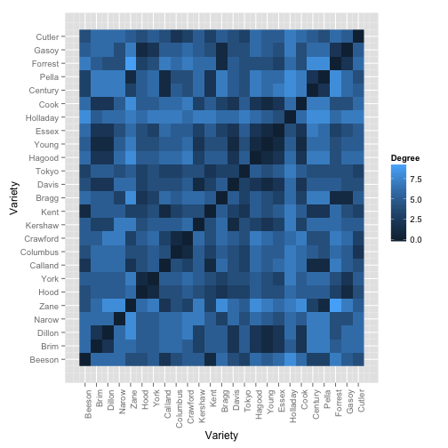

```r
varieties <- c("Beeson", "Brim", "Dillon", "Narow", "Zane", "Hood", "York", "Calland", "Columbus", "Crawford", "Kershaw", "Kent","Bragg", "Davis","Tokyo","Hagood","Young","Essex","Holladay","Cook","Century","Pella","Forrest","Gasoy","Cutler")
heatMapDegreeImage <- plotDegMatrix(varieties,ig,sbTree)
heatMapDegreeImage
```

In a similar function, **plotYearMatrix**, the difference in years between all pairwise combinations of vertices can be constructed and viewed:

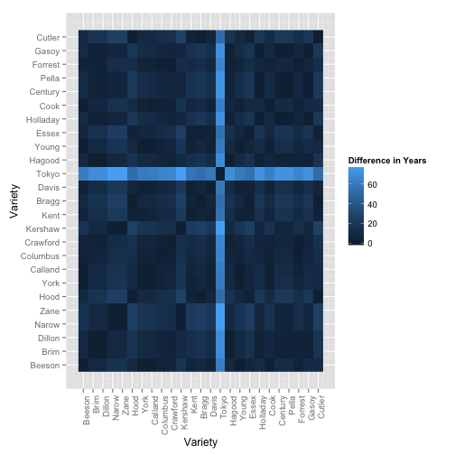

```r
varieties <- c("Beeson", "Brim", "Dillon", "Narow", "Zane", "Hood", "York", "Calland", "Columbus", "Crawford", "Kershaw", "Kent","Bragg", "Davis","Tokyo","Hagood","Young","Essex","Holladay","Cook","Century","Pella","Forrest","Gasoy","Cutler")
heatMapYearImage <- plotYearMatrix(varieties,sbTree)
heatMapYearImage
```

The various options of the **phyViz** package can offer you different ways of visually interpreting your trees that each come with advantages and disadvantages. While some visualizations connect nodes to their years, other visualizations lax this idea, and instead connect nodes based on their generation surrounding a given node. And still other visualizations from **phyViz** will allow you to either focus on one pathway, or view that pathway superimposed across the entire tree for reference. Hopefully, the package will have something to offer to you in your data analysis.